# Testing covariate modelling in hierarchical parent degradation kinetics with residue data on mesotrione

Johannes Ranke

Last change 13 May 2025 (rebuilt 2025-05-13)

# Introduction

The purpose of this document is to test demonstrate how nonlinear hierarchical models (NLHM) based on the parent degradation models SFO, FOMC, DFOP and HS can be fitted with the mkin package, also considering the influence of covariates like soil pH on different degradation parameters. Because in some other case studies, the SFORB parameterisation of biexponential decline has shown some advantages over the DFOP parameterisation, SFORB was included in the list of tested models as well.

The mkin package is used in version 1.2.10, which is contains the functions that were used for the evaluations. The `saemix` package is used as a backend for fitting the NLHM, but is also loaded to make the convergence plot function available.

This document is processed with the `knitr` package, which also provides the `kable` function that is used to improve the display of tabular data in R markdown documents. For parallel processing, the `parallel` package is used.

```r
library(mkin)
library(knitr)
library(saemix)
library(parallel)
n_cores <- detectCores()
if (Sys.info()["sysname"] == "Windows") {
  cl <- makePSOCKcluster(n_cores)
} else {
  cl <- makeForkCluster(n_cores)
}
```

## Test data

```r
data_file <- system.file(
  "testdata", "mesotrione_soil_efsa_2016.xlsx", package = "mkin")
meso_ds <- read_spreadsheet(data_file, parent_only = TRUE)
```

The following tables show the covariate data and the 18 datasets that were read in from the spreadsheet file.

```r
pH <- attr(meso_ds, "covariates")
kable(pH, caption = "Covariate data")
```

Covariate data

|  | pH |
| --- | --- |
| Richmond | 6.2 |
| Richmond 2 | 6.2 |
| ERTC | 6.4 |
| Toulouse | 7.7 |
| Picket Piece | 7.1 |
| 721 | 5.6 |
| 722 | 5.7 |
| 723 | 5.4 |
| 724 | 4.8 |
| 725 | 5.8 |
| 727 | 5.1 |
| 728 | 5.9 |
| 729 | 5.6 |
| 730 | 5.3 |
| 731 | 6.1 |
| 732 | 5.0 |
| 741 | 5.7 |
| 742 | 7.2 |

```r
for (ds_name in names(meso_ds)) {
  print(
    kable(mkin_long_to_wide(meso_ds[[ds_name]]),
      caption = paste("Dataset", ds_name),
      booktabs = TRUE, row.names = FALSE))
}
```

Dataset Richmond

| time | meso |
| --- | --- |
| 0.000000 | 91.00 |
| 1.179050 | 86.70 |
| 3.537149 | 73.60 |
| 7.074299 | 61.50 |
| 10.611448 | 55.70 |
| 15.327647 | 47.70 |
| 17.685747 | 39.50 |
| 24.760046 | 29.80 |
| 35.371494 | 19.60 |
| 68.384889 | 5.67 |
| 0.000000 | 97.90 |
| 1.179050 | 96.40 |
| 3.537149 | 89.10 |
| 7.074299 | 74.40 |
| 10.611448 | 57.40 |
| 15.327647 | 46.30 |
| 18.864797 | 35.50 |
| 27.118146 | 27.20 |
| 35.371494 | 19.10 |
| 74.280138 | 6.50 |
| 108.472582 | 3.40 |
| 142.665027 | 2.20 |

Dataset Richmond 2

| time | meso |
| --- | --- |
| 0.000000 | 96.0 |
| 2.422004 | 82.4 |
| 5.651343 | 71.2 |
| 8.073348 | 53.1 |
| 11.302687 | 48.5 |
| 16.954030 | 33.4 |
| 22.605373 | 24.2 |
| 45.210746 | 11.9 |

Dataset ERTC

| time | meso |
| --- | --- |
| 0.000000 | 99.9 |
| 2.755193 | 80.0 |
| 6.428782 | 42.1 |
| 9.183975 | 50.1 |
| 12.857565 | 28.4 |
| 19.286347 | 39.8 |
| 25.715130 | 29.9 |
| 51.430259 | 2.5 |

Dataset Toulouse

| time | meso |
| --- | --- |
| 0.000000 | 96.8 |
| 2.897983 | 63.3 |
| 6.761960 | 22.3 |
| 9.659942 | 16.6 |
| 13.523919 | 16.1 |
| 20.285879 | 17.2 |
| 27.047838 | 1.8 |

Dataset Picket Piece

| time | meso |
| --- | --- |
| 0.000000 | 102.0 |
| 2.841195 | 73.7 |
| 6.629454 | 35.5 |
| 9.470649 | 31.8 |
| 13.258909 | 18.0 |
| 19.888364 | 3.7 |

Dataset 721

| time | meso |
| --- | --- |
| 0.00000 | 86.4 |
| 11.24366 | 61.4 |
| 22.48733 | 49.8 |
| 33.73099 | 41.0 |
| 44.97466 | 35.1 |

Dataset 722

| time | meso |
| --- | --- |
| 0.00000 | 90.3 |
| 11.24366 | 52.1 |
| 22.48733 | 37.4 |
| 33.73099 | 21.2 |
| 44.97466 | 14.3 |

Dataset 723

| time | meso |
| --- | --- |
| 0.00000 | 89.3 |
| 11.24366 | 70.8 |
| 22.48733 | 51.1 |
| 33.73099 | 42.7 |
| 44.97466 | 26.7 |

Dataset 724

| time | meso |
| --- | --- |
| 0.000000 | 89.4 |
| 9.008208 | 65.2 |
| 18.016415 | 55.8 |
| 27.024623 | 46.0 |
| 36.032831 | 41.7 |

Dataset 725

| time | meso |
| --- | --- |
| 0.00000 | 89.0 |
| 10.99058 | 35.4 |
| 21.98116 | 18.6 |
| 32.97174 | 11.6 |
| 43.96232 | 7.6 |

Dataset 727

| time | meso |
| --- | --- |
| 0.00000 | 91.3 |
| 10.96104 | 63.2 |
| 21.92209 | 51.1 |
| 32.88313 | 42.0 |
| 43.84417 | 40.8 |

Dataset 728

| time | meso |
| --- | --- |
| 0.00000 | 91.8 |
| 11.24366 | 43.6 |
| 22.48733 | 22.0 |
| 33.73099 | 15.9 |
| 44.97466 | 8.8 |

Dataset 729

| time | meso |
| --- | --- |
| 0.00000 | 91.6 |
| 11.24366 | 60.5 |
| 22.48733 | 43.5 |
| 33.73099 | 28.4 |
| 44.97466 | 20.5 |

Dataset 730

| time | meso |
| --- | --- |
| 0.00000 | 92.7 |
| 11.07446 | 58.9 |
| 22.14893 | 44.0 |
| 33.22339 | 46.0 |
| 44.29785 | 29.3 |

Dataset 731

| time | meso |
| --- | --- |
| 0.00000 | 92.1 |
| 11.24366 | 64.4 |
| 22.48733 | 45.3 |
| 33.73099 | 33.6 |
| 44.97466 | 23.5 |

Dataset 732

| time | meso |
| --- | --- |
| 0.00000 | 90.3 |
| 11.24366 | 58.2 |
| 22.48733 | 40.1 |
| 33.73099 | 33.1 |
| 44.97466 | 25.8 |

Dataset 741

| time | meso |
| --- | --- |
| 0.00000 | 90.3 |
| 10.84712 | 68.7 |
| 21.69424 | 58.0 |
| 32.54136 | 52.2 |
| 43.38848 | 48.0 |

Dataset 742

| time | meso |
| --- | --- |
| 0.00000 | 92.0 |
| 11.24366 | 60.9 |
| 22.48733 | 36.2 |
| 33.73099 | 18.3 |
| 44.97466 | 8.7 |

# Separate evaluations

In order to obtain suitable starting parameters for the NLHM fits, separate fits of the five models to the data for each soil are generated using the `mmkin` function from the mkin package. In a first step, constant variance is assumed. Convergence is checked with the `status` function.

```r
deg_mods <- c("SFO", "FOMC", "DFOP", "SFORB", "HS")
f_sep_const <- mmkin(
  deg_mods,
  meso_ds,
  error_model = "const",
  cluster = cl,
  quiet = TRUE)
```

```r
status(f_sep_const[, 1:5]) |> kable()
```

|  | Richmond | Richmond 2 | ERTC | Toulouse | Picket Piece |
| --- | --- | --- | --- | --- | --- |
| SFO | OK | OK | OK | OK | OK |
| FOMC | OK | OK | OK | OK | C |
| DFOP | OK | OK | OK | OK | OK |
| SFORB | OK | OK | OK | OK | OK |
| HS | OK | OK | C | OK | OK |

```r
status(f_sep_const[, 6:18]) |> kable()
```

|  | 721 | 722 | 723 | 724 | 725 | 727 | 728 | 729 | 730 | 731 | 732 | 741 | 742 |
| --- | --- | --- | --- | --- | --- | --- | --- | --- | --- | --- | --- | --- | --- |
| SFO | OK | OK | OK | OK | OK | OK | OK | OK | OK | OK | OK | OK | OK |
| FOMC | OK | OK | C | OK | OK | OK | OK | OK | OK | OK | OK | OK | OK |
| DFOP | OK | OK | OK | OK | OK | OK | OK | OK | OK | OK | OK | OK | OK |
| SFORB | OK | OK | OK | OK | OK | OK | OK | C | OK | OK | OK | OK | OK |
| HS | OK | OK | OK | OK | OK | OK | OK | OK | OK | OK | OK | OK | OK |

In the tables above, OK indicates convergence and C indicates failure to converge. Most separate fits with constant variance converged, with the exception of two FOMC fits, one SFORB fit and one HS fit.

```r
f_sep_tc <- update(f_sep_const, error_model = "tc")
```

```r
status(f_sep_tc[, 1:5]) |> kable()
```

|  | Richmond | Richmond 2 | ERTC | Toulouse | Picket Piece |
| --- | --- | --- | --- | --- | --- |
| SFO | OK | OK | OK | OK | OK |
| FOMC | OK | OK | OK | OK | OK |
| DFOP | C | OK | OK | OK | OK |
| SFORB | OK | OK | OK | OK | OK |
| HS | OK | OK | C | OK | OK |

```r
status(f_sep_tc[, 6:18]) |> kable()
```

|  | 721 | 722 | 723 | 724 | 725 | 727 | 728 | 729 | 730 | 731 | 732 | 741 | 742 |
| --- | --- | --- | --- | --- | --- | --- | --- | --- | --- | --- | --- | --- | --- |
| SFO | OK | OK | OK | OK | OK | OK | OK | OK | OK | OK | OK | OK | OK |
| FOMC | OK | OK | C | OK | C | C | OK | C | OK | C | OK | C | OK |
| DFOP | C | OK | OK | OK | C | OK | OK | OK | OK | C | OK | C | OK |
| SFORB | C | OK | OK | OK | C | OK | OK | C | OK | OK | OK | C | OK |
| HS | OK | OK | OK | OK | OK | OK | OK | OK | OK | C | OK | OK | OK |

With the two-component error model, the set of fits that did not converge is larger, with convergence problems appearing for a number of non-SFO fits.

# Hierarchical models without covariate

The following code fits hierarchical kinetic models for the ten combinations of the five different degradation models with the two different error models in parallel.

```r
f_saem_1 <- mhmkin(list(f_sep_const, f_sep_tc), cluster = cl)
status(f_saem_1) |> kable()
```

|  | const | tc |
| --- | --- | --- |
| SFO | OK | OK |
| FOMC | OK | OK |
| DFOP | OK | OK |
| SFORB | OK | OK |
| HS | OK | OK |

All fits terminate without errors (status OK).

```r
anova(f_saem_1) |> kable(digits = 1)
```

|  | npar | AIC | BIC | Lik |
| --- | --- | --- | --- | --- |
| SFO const | 5 | 800.0 | 804.5 | -395.0 |
| SFO tc | 6 | 801.9 | 807.2 | -394.9 |
| FOMC const | 7 | 787.4 | 793.6 | -386.7 |
| FOMC tc | 8 | 788.9 | 796.1 | -386.5 |
| DFOP const | 9 | 787.6 | 795.6 | -384.8 |
| SFORB const | 9 | 787.4 | 795.4 | -384.7 |
| HS const | 9 | 781.9 | 789.9 | -382.0 |
| DFOP tc | 10 | 787.4 | 796.3 | -383.7 |
| SFORB tc | 10 | 795.8 | 804.7 | -387.9 |
| HS tc | 10 | 783.7 | 792.7 | -381.9 |

```r
illparms(f_saem_1) |> kable()
```

|  | const | tc |
| --- | --- | --- |
| SFO | sd(meso_0) | sd(meso_0), b.1 |
| FOMC | sd(meso_0), sd(log_beta) | sd(meso_0), sd(log_beta), b.1 |
| DFOP | sd(meso_0), sd(log_k1) | sd(meso_0), sd(g_qlogis), b.1 |
| SFORB | sd(meso_free_0), sd(log_k_meso_free_bound) | sd(meso_free_0), sd(log_k_meso_free_bound), b.1 |
| HS | sd(meso_0) | sd(meso_0), b.1 |

For obtaining fits with only well-defined random effects, we update the set of fits, excluding random effects that were ill-defined according to the `illparms` function.

```r
f_saem_2 <- update(f_saem_1, no_random_effect = illparms(f_saem_1))
status(f_saem_2) |> kable()
```

|  | const | tc |
| --- | --- | --- |
| SFO | OK | OK |
| FOMC | OK | OK |
| DFOP | OK | OK |
| SFORB | OK | OK |
| HS | OK | OK |

The updated fits terminate without errors.

```r
illparms(f_saem_2) |> kable()
```

|  | const | tc |
| --- | --- | --- |
| SFO |  | b.1 |
| FOMC |  | b.1 |
| DFOP |  | b.1 |
| SFORB |  | b.1 |
| HS |  | b.1 |

No ill-defined errors remain in the fits with constant variance.

# Hierarchical models with covariate

In the following sections, hierarchical fits including a model for the influence of pH on selected degradation parameters are shown for all parent models. Constant variance is selected as the error model based on the fits without covariate effects. Random effects that were ill-defined in the fits without pH influence are excluded. A potential influence of the soil pH is only included for parameters with a well-defined random effect, because experience has shown that only for such parameters a significant pH effect could be found.

## SFO

```r
sfo_pH <- saem(f_sep_const["SFO", ], no_random_effect = "meso_0", covariates = pH,
  covariate_models = list(log_k_meso ~ pH))
```

```r
summary(sfo_pH)$confint_trans |> kable(digits = 2)
```

|  | est. | lower | upper |
| --- | --- | --- | --- |
| meso_0 | 91.35 | 89.27 | 93.43 |
| log_k_meso | -6.66 | -7.97 | -5.35 |
| beta_pH(log_k_meso) | 0.59 | 0.37 | 0.81 |
| a.1 | 5.48 | 4.71 | 6.24 |
| SD.log_k_meso | 0.35 | 0.23 | 0.47 |

The parameter showing the pH influence in the above table is `beta_pH(log_k_meso)`. Its confidence interval does not include zero, indicating that the influence of soil pH on the log of the degradation rate constant is significantly greater than zero.

```r
anova(f_saem_2[["SFO", "const"]], sfo_pH, test = TRUE)
```

```
Data: 116 observations of 1 variable(s) grouped in 18 datasets

                           npar    AIC    BIC     Lik  Chisq Df Pr(>Chisq)
f_saem_2[["SFO", "const"]]    4 797.56 801.12 -394.78
sfo_pH                        5 783.09 787.54 -386.54 16.473  1  4.934e-05 ***
---
Signif. codes:  0 '***' 0.001 '**' 0.01 '*' 0.05 '.' 0.1 ' ' 1
```

The comparison with the SFO fit without covariate effect confirms that considering the soil pH improves the model, both by comparison of AIC and BIC and by the likelihood ratio test.

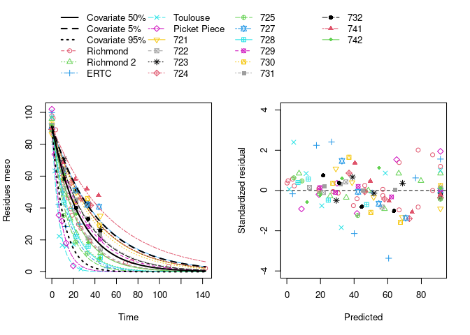

```r
plot(sfo_pH)
```

Endpoints for a model with covariates are by default calculated for the median of the covariate values. This quantile can be adapted, or a specific covariate value can be given as shown below.

```r
endpoints(sfo_pH)
```

```
$covariates
      pH
50% 5.75

$distimes
         DT50     DT90
meso 18.52069 61.52441
```

```r
endpoints(sfo_pH, covariate_quantile = 0.9)
```

```
$covariates
      pH
90% 7.13

$distimes
         DT50     DT90
meso 8.237019 27.36278
```

```r
endpoints(sfo_pH, covariates = c(pH = 7.0))
```

```
$covariates
     pH
User  7

$distimes
        DT50    DT90
meso 8.89035 29.5331
```

## FOMC

```r
fomc_pH <- saem(f_sep_const["FOMC", ], no_random_effect = "meso_0", covariates = pH,
  covariate_models = list(log_alpha ~ pH))
```

```r
summary(fomc_pH)$confint_trans |> kable(digits = 2)
```

|  | est. | lower | upper |
| --- | --- | --- | --- |
| meso_0 | 92.84 | 90.75 | 94.93 |
| log_alpha | -2.21 | -3.49 | -0.92 |
| beta_pH(log_alpha) | 0.58 | 0.37 | 0.79 |
| log_beta | 4.21 | 3.44 | 4.99 |
| a.1 | 5.03 | 4.32 | 5.73 |
| SD.log_alpha | 0.00 | -23.77 | 23.78 |
| SD.log_beta | 0.37 | 0.01 | 0.74 |

As in the case of SFO, the confidence interval of the slope parameter (here `beta_pH(log_alpha)`) quantifying the influence of soil pH does not include zero, and the model comparison clearly indicates that the model with covariate influence is preferable. However, the random effect for `alpha` is not well-defined any more after inclusion of the covariate effect (the confidence interval of `SD.log_alpha` includes zero).

```r
illparms(fomc_pH)
```

```
[1] "sd(log_alpha)"
```

Therefore, the model is updated without this random effect, and no ill-defined parameters remain.

```r
fomc_pH_2 <- update(fomc_pH, no_random_effect = c("meso_0", "log_alpha"))
illparms(fomc_pH_2)
```

```r
anova(f_saem_2[["FOMC", "const"]], fomc_pH, fomc_pH_2, test = TRUE)
```

```
Data: 116 observations of 1 variable(s) grouped in 18 datasets

                            npar    AIC    BIC     Lik  Chisq Df Pr(>Chisq)
f_saem_2[["FOMC", "const"]]    5 783.25 787.71 -386.63
fomc_pH_2                      6 767.49 772.83 -377.75 17.762  1  2.503e-05 ***
fomc_pH                        7 770.07 776.30 -378.04  0.000  1          1
---
Signif. codes:  0 '***' 0.001 '**' 0.01 '*' 0.05 '.' 0.1 ' ' 1
```

Model comparison indicates that including pH dependence significantly improves the fit, and that the reduced model with covariate influence results in the most preferable FOMC fit.

```r
summary(fomc_pH_2)$confint_trans |> kable(digits = 2)
```

|  | est. | lower | upper |
| --- | --- | --- | --- |
| meso_0 | 93.05 | 90.98 | 95.13 |
| log_alpha | -2.91 | -4.18 | -1.63 |
| beta_pH(log_alpha) | 0.66 | 0.44 | 0.87 |
| log_beta | 3.95 | 3.29 | 4.62 |
| a.1 | 4.98 | 4.28 | 5.68 |
| SD.log_beta | 0.40 | 0.26 | 0.54 |

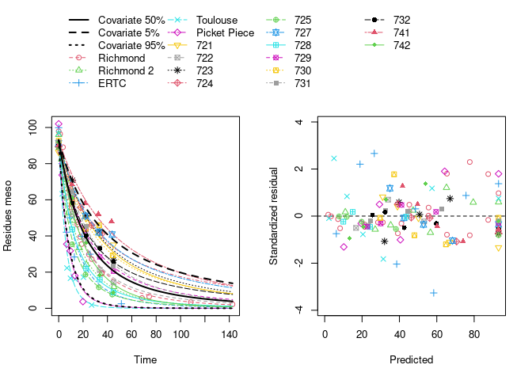

```r
plot(fomc_pH_2)
```

```r
endpoints(fomc_pH_2)
```

```
$covariates
      pH
50% 5.75

$distimes
         DT50     DT90 DT50back
meso 17.30248 82.91343 24.95943
```

```r
endpoints(fomc_pH_2, covariates = c(pH = 7))
```

```
$covariates
     pH
User  7

$distimes
         DT50     DT90 DT50back
meso 6.986239 27.02927 8.136621
```

## DFOP

In the DFOP fits without covariate effects, random effects for two degradation parameters (`k2` and `g`) were identifiable.

```r
summary(f_saem_2[["DFOP", "const"]])$confint_trans |> kable(digits = 2)
```

|  | est. | lower | upper |
| --- | --- | --- | --- |
| meso_0 | 93.61 | 91.58 | 95.63 |
| log_k1 | -1.53 | -2.27 | -0.79 |
| log_k2 | -3.42 | -3.73 | -3.11 |
| g_qlogis | -1.67 | -2.57 | -0.77 |
| a.1 | 4.74 | 4.02 | 5.45 |
| SD.log_k2 | 0.60 | 0.38 | 0.81 |
| SD.g_qlogis | 0.94 | 0.33 | 1.54 |

A fit with pH dependent degradation parameters was obtained by excluding the same random effects as in the refined DFOP fit without covariate influence, and including covariate models for the two identifiable parameters `k2` and `g`.

```r
dfop_pH <- saem(f_sep_const["DFOP", ], no_random_effect = c("meso_0", "log_k1"),
  covariates = pH,
  covariate_models = list(log_k2 ~ pH, g_qlogis ~ pH))
```

The corresponding parameters for the influence of soil pH are `beta_pH(log_k2)` for the influence of soil pH on `k2`, and `beta_pH(g_qlogis)` for its influence on `g`.

```r
summary(dfop_pH)$confint_trans |> kable(digits = 2)
```

|  | est. | lower | upper |
| --- | --- | --- | --- |
| meso_0 | 92.84 | 90.85 | 94.84 |
| log_k1 | -2.82 | -3.09 | -2.54 |
| log_k2 | -11.48 | -15.32 | -7.64 |
| beta_pH(log_k2) | 1.31 | 0.69 | 1.92 |
| g_qlogis | 3.13 | 0.47 | 5.80 |
| beta_pH(g_qlogis) | -0.57 | -1.04 | -0.09 |
| a.1 | 4.96 | 4.26 | 5.65 |
| SD.log_k2 | 0.76 | 0.47 | 1.05 |
| SD.g_qlogis | 0.01 | -9.96 | 9.97 |

```r
illparms(dfop_pH)
```

```
[1] "sd(g_qlogis)"
```

Confidence intervals for neither of them include zero, indicating a significant difference from zero. However, the random effect for `g` is now ill-defined. The fit is updated without this ill-defined random effect.

```r
dfop_pH_2 <- update(dfop_pH,
  no_random_effect = c("meso_0", "log_k1", "g_qlogis"))
illparms(dfop_pH_2)
```

```
[1] "beta_pH(g_qlogis)"
```

Now, the slope parameter for the pH effect on `g` is ill-defined. Therefore, another attempt is made without the corresponding covariate model.

```r
dfop_pH_3 <- saem(f_sep_const["DFOP", ], no_random_effect = c("meso_0", "log_k1"),
  covariates = pH,
  covariate_models = list(log_k2 ~ pH))
illparms(dfop_pH_3)
```

```
[1] "sd(g_qlogis)"
```

As the random effect for `g` is again ill-defined, the fit is repeated without it.

```r
dfop_pH_4 <- update(dfop_pH_3, no_random_effect = c("meso_0", "log_k1", "g_qlogis"))
illparms(dfop_pH_4)
```

While no ill-defined parameters remain, model comparison suggests that the previous model `dfop_pH_2` with two pH dependent parameters is preferable, based on information criteria as well as based on the likelihood ratio test.

```r
anova(f_saem_2[["DFOP", "const"]], dfop_pH, dfop_pH_2, dfop_pH_3, dfop_pH_4)
```

```
Data: 116 observations of 1 variable(s) grouped in 18 datasets

                            npar    AIC    BIC     Lik
f_saem_2[["DFOP", "const"]]    7 782.94 789.18 -384.47
dfop_pH_4                      7 767.35 773.58 -376.68
dfop_pH_2                      8 765.14 772.26 -374.57
dfop_pH_3                      8 769.00 776.12 -376.50
dfop_pH                        9 769.10 777.11 -375.55
```

```r
anova(dfop_pH_2, dfop_pH_4, test = TRUE)
```

```
Data: 116 observations of 1 variable(s) grouped in 18 datasets

          npar    AIC    BIC     Lik  Chisq Df Pr(>Chisq)
dfop_pH_4    7 767.35 773.58 -376.68
dfop_pH_2    8 765.14 772.26 -374.57 4.2153  1    0.04006 *
---
Signif. codes:  0 '***' 0.001 '**' 0.01 '*' 0.05 '.' 0.1 ' ' 1
```

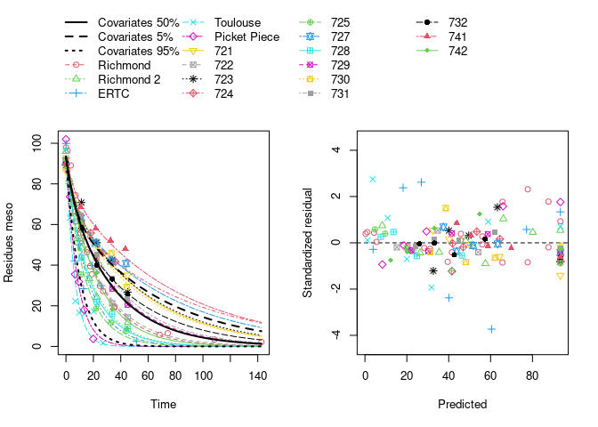

```r
plot(dfop_pH_2)
```

```r
endpoints(dfop_pH_2)
```

```
$covariates
      pH
50% 5.75

$distimes
         DT50     DT90 DT50back  DT50_k1  DT50_k2
meso 18.36876 73.51841 22.13125 4.191901 23.98672
```

```r
endpoints(dfop_pH_2, covariates = c(pH = 7))
```

```
$covariates
     pH
User  7

$distimes
         DT50     DT90 DT50back  DT50_k1  DT50_k2
meso 8.346428 28.34437 8.532507 4.191901 8.753618
```

## SFORB

```r
sforb_pH <- saem(f_sep_const["SFORB", ], no_random_effect = c("meso_free_0", "log_k_meso_free_bound"),
  covariates = pH,
  covariate_models = list(log_k_meso_free ~ pH, log_k_meso_bound_free ~ pH))
```

```r
summary(sforb_pH)$confint_trans |> kable(digits = 2)
```

|  | est. | lower | upper |
| --- | --- | --- | --- |
| meso_free_0 | 93.42 | 91.32 | 95.52 |
| log_k_meso_free | -5.37 | -6.94 | -3.81 |
| beta_pH(log_k_meso_free) | 0.42 | 0.18 | 0.67 |
| log_k_meso_free_bound | -3.49 | -4.92 | -2.05 |
| log_k_meso_bound_free | -9.98 | -19.22 | -0.74 |
| beta_pH(log_k_meso_bound_free) | 1.23 | -0.21 | 2.67 |
| a.1 | 4.90 | 4.18 | 5.63 |
| SD.log_k_meso_free | 0.35 | 0.23 | 0.47 |
| SD.log_k_meso_bound_free | 0.13 | -1.95 | 2.20 |

The confidence interval of `beta_pH(log_k_meso_bound_free)` includes zero, indicating that the influence of soil pH on `k_meso_bound_free` cannot reliably be quantified. Also, the confidence interval for the random effect on this parameter (`SD.log_k_meso_bound_free`) includes zero.

Using the `illparms` function, these ill-defined parameters can be found more conveniently.

```r
illparms(sforb_pH)
```

```
[1] "sd(log_k_meso_bound_free)"      "beta_pH(log_k_meso_bound_free)"
```

To remove the ill-defined parameters, a second variant of the SFORB model with pH influence is fitted. No ill-defined parameters remain.

```r
sforb_pH_2 <- update(sforb_pH,
  no_random_effect = c("meso_free_0", "log_k_meso_free_bound", "log_k_meso_bound_free"),
  covariate_models = list(log_k_meso_free ~ pH))
illparms(sforb_pH_2)
```

The model comparison of the SFORB fits includes the refined model without covariate effect, and both versions of the SFORB fit with covariate effect.

```r
anova(f_saem_2[["SFORB", "const"]], sforb_pH, sforb_pH_2, test = TRUE)
```

```
Data: 116 observations of 1 variable(s) grouped in 18 datasets

                             npar    AIC    BIC     Lik   Chisq Df Pr(>Chisq)
f_saem_2[["SFORB", "const"]]    7 783.40 789.63 -384.70
sforb_pH_2                      7 770.94 777.17 -378.47 12.4616  0
sforb_pH                        9 768.81 776.83 -375.41  6.1258  2    0.04675 *
---
Signif. codes:  0 '***' 0.001 '**' 0.01 '*' 0.05 '.' 0.1 ' ' 1
```

The first model including pH influence is preferable based on information criteria and the likelihood ratio test. However, as it is not fully identifiable, the second model is selected.

```r
summary(sforb_pH_2)$confint_trans |> kable(digits = 2)
```

|  | est. | lower | upper |
| --- | --- | --- | --- |
| meso_free_0 | 93.32 | 91.16 | 95.48 |
| log_k_meso_free | -6.15 | -7.43 | -4.86 |
| beta_pH(log_k_meso_free) | 0.54 | 0.33 | 0.75 |
| log_k_meso_free_bound | -3.80 | -5.20 | -2.40 |
| log_k_meso_bound_free | -2.95 | -4.26 | -1.64 |
| a.1 | 5.08 | 4.38 | 5.79 |
| SD.log_k_meso_free | 0.33 | 0.22 | 0.45 |

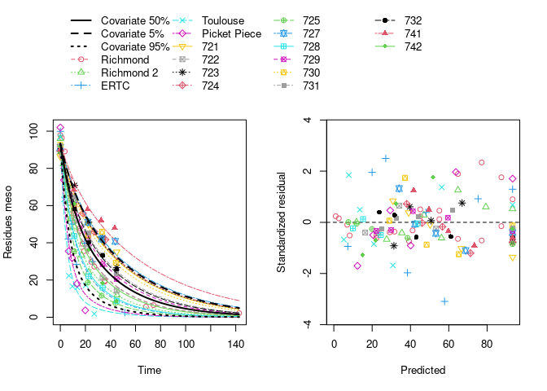

```r
plot(sforb_pH_2)
```

```r
endpoints(sforb_pH_2)
```

```
$covariates
      pH
50% 5.75

$ff
meso_free
        1

$SFORB
   meso_b1    meso_b2     meso_g
0.09735824 0.02631699 0.31602120

$distimes
         DT50     DT90 DT50back DT50_meso_b1 DT50_meso_b2
meso 16.86549 73.15824 22.02282     7.119554     26.33839
```

```r
endpoints(sforb_pH_2, covariates = c(pH = 7))
```

```
$covariates
     pH
User  7

$ff
meso_free
        1

$SFORB
   meso_b1    meso_b2     meso_g
0.13315233 0.03795988 0.61186191

$distimes
         DT50     DT90 DT50back DT50_meso_b1 DT50_meso_b2
meso 7.932495 36.93311 11.11797     5.205671        18.26
```

## HS

```r
hs_pH <- saem(f_sep_const["HS", ], no_random_effect = c("meso_0"),
  covariates = pH,
  covariate_models = list(log_k1 ~ pH, log_k2 ~ pH, log_tb ~ pH))
```

```r
summary(hs_pH)$confint_trans |> kable(digits = 2)
```

|  | est. | lower | upper |
| --- | --- | --- | --- |
| meso_0 | 93.33 | 91.47 | 95.19 |
| log_k1 | -5.81 | -7.27 | -4.36 |
| beta_pH(log_k1) | 0.47 | 0.23 | 0.72 |
| log_k2 | -6.80 | -8.76 | -4.83 |
| beta_pH(log_k2) | 0.54 | 0.21 | 0.87 |
| log_tb | 3.25 | 1.25 | 5.25 |
| beta_pH(log_tb) | -0.10 | -0.43 | 0.23 |
| a.1 | 4.49 | 3.78 | 5.21 |
| SD.log_k1 | 0.37 | 0.24 | 0.51 |
| SD.log_k2 | 0.29 | 0.10 | 0.48 |
| SD.log_tb | 0.25 | -0.07 | 0.57 |

```r
illparms(hs_pH)
```

```
[1] "sd(log_tb)"      "beta_pH(log_tb)"
```

According to the output of the `illparms` function, the random effect on the break time `tb` cannot reliably be quantified, neither can the influence of soil pH on `tb`. The fit is repeated without the corresponding covariate model, and no ill-defined parameters remain.

```r
hs_pH_2 <- update(hs_pH, covariate_models = list(log_k1 ~ pH, log_k2 ~ pH))
illparms(hs_pH_2)
```

Model comparison confirms that this model is preferable to the fit without covariate influence, and also to the first version with covariate influence.

```r
anova(f_saem_2[["HS", "const"]], hs_pH, hs_pH_2, test = TRUE)
```

```
Data: 116 observations of 1 variable(s) grouped in 18 datasets

                          npar    AIC    BIC     Lik  Chisq Df Pr(>Chisq)
f_saem_2[["HS", "const"]]    8 780.08 787.20 -382.04
hs_pH_2                     10 766.47 775.37 -373.23 17.606  2  0.0001503 ***
hs_pH                       11 769.80 779.59 -373.90  0.000  1  1.0000000
---
Signif. codes:  0 '***' 0.001 '**' 0.01 '*' 0.05 '.' 0.1 ' ' 1
```

```r
summary(hs_pH_2)$confint_trans |> kable(digits = 2)
```

|  | est. | lower | upper |
| --- | --- | --- | --- |
| meso_0 | 93.33 | 91.50 | 95.15 |
| log_k1 | -5.68 | -7.09 | -4.27 |
| beta_pH(log_k1) | 0.46 | 0.22 | 0.69 |
| log_k2 | -6.61 | -8.34 | -4.88 |
| beta_pH(log_k2) | 0.50 | 0.21 | 0.79 |
| log_tb | 2.70 | 2.33 | 3.08 |
| a.1 | 4.45 | 3.74 | 5.16 |
| SD.log_k1 | 0.36 | 0.22 | 0.49 |
| SD.log_k2 | 0.23 | 0.02 | 0.43 |
| SD.log_tb | 0.55 | 0.25 | 0.85 |

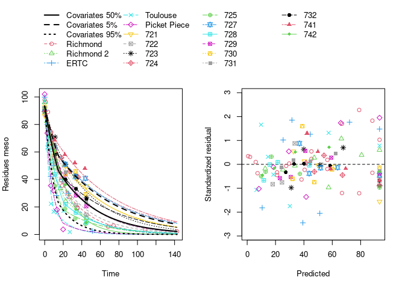

```r
plot(hs_pH_2)
```

```r
endpoints(hs_pH_2)
```

```
$covariates
      pH
50% 5.75

$distimes
         DT50     DT90 DT50back  DT50_k1  DT50_k2
meso 14.68725 82.45287 24.82079 14.68725 29.29299
```

```r
endpoints(hs_pH_2, covariates = c(pH = 7))
```

```
$covariates
     pH
User  7

$distimes
         DT50     DT90 DT50back  DT50_k1  DT50_k2
meso 8.298536 38.85371 11.69613 8.298536 15.71561
```

## Comparison across parent models

After model reduction for all models with pH influence, they are compared with each other.

```r
anova(sfo_pH, fomc_pH_2, dfop_pH_2, dfop_pH_4, sforb_pH_2, hs_pH_2)
```

```
Data: 116 observations of 1 variable(s) grouped in 18 datasets

           npar    AIC    BIC     Lik
sfo_pH        5 783.09 787.54 -386.54
fomc_pH_2     6 767.49 772.83 -377.75
dfop_pH_4     7 767.35 773.58 -376.68
sforb_pH_2    7 770.94 777.17 -378.47
dfop_pH_2     8 765.14 772.26 -374.57
hs_pH_2      10 766.47 775.37 -373.23
```

The DFOP model with pH influence on `k2` and `g` and a random effect only on `k2` is finally selected as the best fit.

The endpoints resulting from this model are listed below. Please refer to the Appendix for a detailed listing.

```r
endpoints(dfop_pH_2)
```

```
$covariates
      pH
50% 5.75

$distimes
         DT50     DT90 DT50back  DT50_k1  DT50_k2
meso 18.36876 73.51841 22.13125 4.191901 23.98672
```

```r
endpoints(dfop_pH_2, covariates = c(pH = 7))
```

```
$covariates
     pH
User  7

$distimes
         DT50     DT90 DT50back  DT50_k1  DT50_k2
meso 8.346428 28.34437 8.532507 4.191901 8.753618
```

# Conclusions

These evaluations demonstrate that covariate effects can be included for all types of parent degradation models. These models can then be further refined to make them fully identifiable.

# Appendix

## Hierarchical fit listings

### Fits without covariate effects

Hierarchical SFO fit with constant variance

```
saemix version used for fitting:      3.3
mkin version used for pre-fitting:  1.2.10
R version used for fitting:         4.5.0
Date of fit:     Tue May 13 06:54:35 2025
Date of summary: Tue May 13 07:05:04 2025

Equations:
d_meso/dt = - k_meso * meso

Data:
116 observations of 1 variable(s) grouped in 18 datasets

Model predictions using solution type analytical

Fitted in 0.573 s
Using 300, 100 iterations and 3 chains

Variance model: Constant variance

Starting values for degradation parameters:
    meso_0 log_k_meso
    90.832     -3.192

Fixed degradation parameter values:
None

Starting values for random effects (square root of initial entries in omega):
           meso_0 log_k_meso
meso_0      6.752     0.0000
log_k_meso  0.000     0.9155

Starting values for error model parameters:
a.1
  1

Results:

Likelihood computed by importance sampling
  AIC   BIC logLik
  800 804.5   -395
```

[output cut: 15 more lines]

```
SD.meso_0     0.0611 -98.3545 98.4767
SD.log_k_meso 0.5616   0.3734  0.7499

Variance model:
     est. lower upper
a.1 5.463 4.642 6.284

Backtransformed parameters:
           est.    lower    upper
meso_0 92.07053 89.99172 94.14933
k_meso  0.04225  0.03243  0.05505

Estimated disappearance times:
      DT50 DT90
meso 16.41 54.5
```

Hierarchical FOMC fit with constant variance

```
saemix version used for fitting:      3.3
mkin version used for pre-fitting:  1.2.10
R version used for fitting:         4.5.0
Date of fit:     Tue May 13 06:54:36 2025
Date of summary: Tue May 13 07:05:04 2025

Equations:
d_meso/dt = - (alpha/beta) * 1/((time/beta) + 1) * meso

Data:
116 observations of 1 variable(s) grouped in 18 datasets

Model predictions using solution type analytical

Fitted in 0.832 s
Using 300, 100 iterations and 3 chains

Variance model: Constant variance

Starting values for degradation parameters:
   meso_0 log_alpha  log_beta
  93.0520    0.6008    3.4176

Fixed degradation parameter values:
None

Starting values for random effects (square root of initial entries in omega):
          meso_0 log_alpha log_beta
meso_0     6.287      0.00    0.000
log_alpha  0.000      1.53    0.000
log_beta   0.000      0.00    1.724

Starting values for error model parameters:
a.1
  1

Results:

Likelihood computed by importance sampling
    AIC   BIC logLik
```

[output cut: 21 more lines]

```
SD.log_beta  0.3903  -0.06074  0.8414

Variance model:
     est. lower upper
a.1 5.071 4.298 5.843

Backtransformed parameters:
         est.  lower  upper
meso_0 93.565 91.429 95.701
alpha   2.148  1.324  3.485
beta   38.850 21.327 70.770

Estimated disappearance times:
     DT50  DT90 DT50back
meso 14.8 74.64    22.47
```

Hierarchical DFOP fit with constant variance

```
saemix version used for fitting:      3.3
mkin version used for pre-fitting:  1.2.10
R version used for fitting:         4.5.0
Date of fit:     Tue May 13 06:54:36 2025
Date of summary: Tue May 13 07:05:04 2025

Equations:
d_meso/dt = - ((k1 * g * exp(-k1 * time) + k2 * (1 - g) * exp(-k2 *
           time)) / (g * exp(-k1 * time) + (1 - g) * exp(-k2 * time)))
           * meso

Data:
116 observations of 1 variable(s) grouped in 18 datasets

Model predictions using solution type analytical

Fitted in 1.483 s
Using 300, 100 iterations and 3 chains

Variance model: Constant variance

Starting values for degradation parameters:
  meso_0   log_k1   log_k2 g_qlogis
93.14689 -2.05241 -3.53079 -0.09522

Fixed degradation parameter values:
None

Starting values for random effects (square root of initial entries in omega):
         meso_0 log_k1 log_k2 g_qlogis
meso_0    6.418  0.000  0.000     0.00
log_k1    0.000  1.018  0.000     0.00
log_k2    0.000  0.000  1.694     0.00
g_qlogis  0.000  0.000  0.000     2.37

Starting values for error model parameters:
a.1
  1

Results:
```

[output cut: 29 more lines]

```

Variance model:
    est. lower upper
a.1 4.78 4.013 5.548

Backtransformed parameters:
           est.    lower    upper
meso_0 93.66841 91.63599 95.70082
k1      0.17633  0.07322  0.42466
k2      0.03332  0.02392  0.04643
g       0.16327  0.06529  0.35277

Estimated disappearance times:
      DT50  DT90 DT50back DT50_k1 DT50_k2
meso 16.04 63.75    19.19   3.931    20.8
```

Hierarchical SFORB fit with constant variance

```
saemix version used for fitting:      3.3
mkin version used for pre-fitting:  1.2.10
R version used for fitting:         4.5.0
Date of fit:     Tue May 13 06:54:37 2025
Date of summary: Tue May 13 07:05:04 2025

Equations:
d_meso_free/dt = - k_meso_free * meso_free - k_meso_free_bound *
           meso_free + k_meso_bound_free * meso_bound
d_meso_bound/dt = + k_meso_free_bound * meso_free - k_meso_bound_free *
           meso_bound

Data:
116 observations of 1 variable(s) grouped in 18 datasets

Model predictions using solution type analytical

Fitted in 1.563 s
Using 300, 100 iterations and 3 chains

Variance model: Constant variance

Starting values for degradation parameters:
          meso_free_0       log_k_meso_free log_k_meso_free_bound
               93.147                -2.305                -4.230
log_k_meso_bound_free
               -3.761

Fixed degradation parameter values:
None

Starting values for random effects (square root of initial entries in omega):
                      meso_free_0 log_k_meso_free log_k_meso_free_bound
meso_free_0                 6.418          0.0000                 0.000
log_k_meso_free             0.000          0.9276                 0.000
log_k_meso_free_bound       0.000          0.0000                 2.272
log_k_meso_bound_free       0.000          0.0000                 0.000
                      log_k_meso_bound_free
meso_free_0                           0.000
log_k_meso_free                       0.000
```

[output cut: 45 more lines]

```
k_meso_free        0.05893  0.04339  0.08004
k_meso_free_bound  0.03990  0.01145  0.13903
k_meso_bound_free  0.08851  0.02825  0.27736

Estimated Eigenvalues of SFORB model(s):
meso_b1 meso_b2  meso_g
0.15333 0.03402 0.20881

Resulting formation fractions:
          ff
meso_free  1

Estimated disappearance times:
      DT50  DT90 DT50back DT50_meso_b1 DT50_meso_b2
meso 14.79 60.81     18.3        4.521        20.37
```

Hierarchical HS fit with constant variance

```
saemix version used for fitting:      3.3
mkin version used for pre-fitting:  1.2.10
R version used for fitting:         4.5.0
Date of fit:     Tue May 13 06:54:37 2025
Date of summary: Tue May 13 07:05:04 2025

Equations:
d_meso/dt = - ifelse(time <= tb, k1, k2) * meso

Data:
116 observations of 1 variable(s) grouped in 18 datasets

Model predictions using solution type analytical

Fitted in 1.457 s
Using 300, 100 iterations and 3 chains

Variance model: Constant variance

Starting values for degradation parameters:
meso_0 log_k1 log_k2 log_tb
92.920 -2.409 -3.295  2.471

Fixed degradation parameter values:
None

Starting values for random effects (square root of initial entries in omega):
       meso_0 log_k1 log_k2 log_tb
meso_0  6.477 0.0000 0.0000   0.00
log_k1  0.000 0.8675 0.0000   0.00
log_k2  0.000 0.0000 0.4035   0.00
log_tb  0.000 0.0000 0.0000   1.16

Starting values for error model parameters:
a.1
  1

Results:

Likelihood computed by importance sampling
```

[output cut: 27 more lines]

```

Variance model:
     est. lower upper
a.1 4.477 3.706 5.248

Backtransformed parameters:
           est.    lower    upper
meso_0 93.34242 91.47303 95.21181
k1      0.06247  0.04584  0.08512
k2      0.02682  0.02143  0.03357
tb      7.40872  3.80282 14.43376

Estimated disappearance times:
     DT50 DT90 DT50back DT50_k1 DT50_k2
meso   16   76    22.88    11.1   25.84
```

### Fits with covariate effects

Hierarchichal SFO fit with pH influence

```
saemix version used for fitting:      3.3
mkin version used for pre-fitting:  1.2.10
R version used for fitting:         4.5.0
Date of fit:     Tue May 13 06:54:52 2025
Date of summary: Tue May 13 07:05:04 2025

Equations:
d_meso/dt = - k_meso * meso

Data:
116 observations of 1 variable(s) grouped in 18 datasets

Model predictions using solution type analytical

Fitted in 1.802 s
Using 300, 100 iterations and 3 chains

Variance model: Constant variance

Starting values for degradation parameters:
    meso_0 log_k_meso
    90.832     -3.192

Fixed degradation parameter values:
None

Starting values for random effects (square root of initial entries in omega):
           meso_0 log_k_meso
meso_0      6.752     0.0000
log_k_meso  0.000     0.9155

Starting values for error model parameters:
a.1
  1

Results:

Likelihood computed by importance sampling
    AIC   BIC logLik
  783.1 787.5 -386.5
```

[output cut: 19 more lines]

```
     est. lower upper
a.1 5.475 4.709 6.242

Backtransformed parameters:
            est.     lower     upper
meso_0 91.348139 8.927e+01 93.427476
k_meso  0.001279 3.452e-04  0.004741

Covariates used for endpoints below:
      pH
50% 5.75

Estimated disappearance times:
      DT50  DT90
meso 18.52 61.52
```

Hierarchichal FOMC fit with pH influence

```
saemix version used for fitting:      3.3
mkin version used for pre-fitting:  1.2.10
R version used for fitting:         4.5.0
Date of fit:     Tue May 13 06:54:54 2025
Date of summary: Tue May 13 07:05:04 2025

Equations:
d_meso/dt = - (alpha/beta) * 1/((time/beta) + 1) * meso

Data:
116 observations of 1 variable(s) grouped in 18 datasets

Model predictions using solution type analytical

Fitted in 1.512 s
Using 300, 100 iterations and 3 chains

Variance model: Constant variance

Starting values for degradation parameters:
   meso_0 log_alpha  log_beta
  93.0520    0.6008    3.4176

Fixed degradation parameter values:
None

Starting values for random effects (square root of initial entries in omega):
          meso_0 log_alpha log_beta
meso_0     6.287      0.00    0.000
log_alpha  0.000      1.53    0.000
log_beta   0.000      0.00    1.724

Starting values for error model parameters:
a.1
  1

Results:

Likelihood computed by importance sampling
    AIC   BIC logLik
```

[output cut: 25 more lines]

```
a.1 5.028 4.322 5.734

Backtransformed parameters:
          est.    lower    upper
meso_0 92.8406 90.75046  94.9308
alpha   0.1101  0.03036   0.3991
beta   67.6332 31.15113 146.8404

Covariates used for endpoints below:
      pH
50% 5.75

Estimated disappearance times:
      DT50  DT90 DT50back
meso 17.28 76.37    22.99
```

Refined hierarchichal FOMC fit with pH influence

```
saemix version used for fitting:      3.3
mkin version used for pre-fitting:  1.2.10
R version used for fitting:         4.5.0
Date of fit:     Tue May 13 06:54:57 2025
Date of summary: Tue May 13 07:05:04 2025

Equations:
d_meso/dt = - (alpha/beta) * 1/((time/beta) + 1) * meso

Data:
116 observations of 1 variable(s) grouped in 18 datasets

Model predictions using solution type analytical

Fitted in 2.52 s
Using 300, 100 iterations and 3 chains

Variance model: Constant variance

Starting values for degradation parameters:
   meso_0 log_alpha  log_beta
  93.0520    0.6008    3.4176

Fixed degradation parameter values:
None

Starting values for random effects (square root of initial entries in omega):
          meso_0 log_alpha log_beta
meso_0     6.287      0.00    0.000
log_alpha  0.000      1.53    0.000
log_beta   0.000      0.00    1.724

Starting values for error model parameters:
a.1
  1

Results:

Likelihood computed by importance sampling
    AIC   BIC logLik
```

[output cut: 23 more lines]

```
a.1 4.978 4.281 5.675

Backtransformed parameters:
           est.    lower    upper
meso_0 93.05359 90.97713  95.1300
alpha   0.05473  0.01529   0.1958
beta   52.19251 26.73597 101.8874

Covariates used for endpoints below:
      pH
50% 5.75

Estimated disappearance times:
     DT50  DT90 DT50back
meso 17.3 82.91    24.96
```

Hierarchichal DFOP fit with pH influence

```
saemix version used for fitting:      3.3
mkin version used for pre-fitting:  1.2.10
R version used for fitting:         4.5.0
Date of fit:     Tue May 13 06:55:00 2025
Date of summary: Tue May 13 07:05:04 2025

Equations:
d_meso/dt = - ((k1 * g * exp(-k1 * time) + k2 * (1 - g) * exp(-k2 *
           time)) / (g * exp(-k1 * time) + (1 - g) * exp(-k2 * time)))
           * meso

Data:
116 observations of 1 variable(s) grouped in 18 datasets

Model predictions using solution type analytical

Fitted in 2.218 s
Using 300, 100 iterations and 3 chains

Variance model: Constant variance

Starting values for degradation parameters:
  meso_0   log_k1   log_k2 g_qlogis
93.14689 -2.05241 -3.53079 -0.09522

Fixed degradation parameter values:
None

Starting values for random effects (square root of initial entries in omega):
         meso_0 log_k1 log_k2 g_qlogis
meso_0    6.418  0.000  0.000     0.00
log_k1    0.000  1.018  0.000     0.00
log_k2    0.000  0.000  1.694     0.00
g_qlogis  0.000  0.000  0.000     2.37

Starting values for error model parameters:
a.1
  1

Results:
```

[output cut: 33 more lines]

```

Backtransformed parameters:
            est.     lower     upper
meso_0 9.284e+01 9.085e+01 9.484e+01
k1     5.986e-02 4.556e-02 7.866e-02
k2     1.034e-05 2.221e-07 4.812e-04
g      9.582e-01 6.144e-01 9.970e-01

Covariates used for endpoints below:
      pH
50% 5.75

Estimated disappearance times:
      DT50  DT90 DT50back DT50_k1 DT50_k2
meso 20.23 88.45    26.62   11.58   36.23
```

Refined hierarchical DFOP fit with pH influence

```
saemix version used for fitting:      3.3
mkin version used for pre-fitting:  1.2.10
R version used for fitting:         4.5.0
Date of fit:     Tue May 13 06:55:05 2025
Date of summary: Tue May 13 07:05:04 2025

Equations:
d_meso/dt = - ((k1 * g * exp(-k1 * time) + k2 * (1 - g) * exp(-k2 *
           time)) / (g * exp(-k1 * time) + (1 - g) * exp(-k2 * time)))
           * meso

Data:
116 observations of 1 variable(s) grouped in 18 datasets

Model predictions using solution type analytical

Fitted in 4.711 s
Using 300, 100 iterations and 3 chains

Variance model: Constant variance

Starting values for degradation parameters:
  meso_0   log_k1   log_k2 g_qlogis
93.14689 -2.05241 -3.53079 -0.09522

Fixed degradation parameter values:
None

Starting values for random effects (square root of initial entries in omega):
         meso_0 log_k1 log_k2 g_qlogis
meso_0    6.418  0.000  0.000     0.00
log_k1    0.000  1.018  0.000     0.00
log_k2    0.000  0.000  1.694     0.00
g_qlogis  0.000  0.000  0.000     2.37

Starting values for error model parameters:
a.1
  1

Results:
```

[output cut: 31 more lines]

```

Backtransformed parameters:
            est.     lower    upper
meso_0 9.333e+01 9.124e+01 95.42394
k1     1.654e-01 5.435e-02  0.50309
k2     2.799e-04 3.785e-05  0.00207
g      9.661e-01 2.352e-01  0.99962

Covariates used for endpoints below:
      pH
50% 5.75

Estimated disappearance times:
      DT50  DT90 DT50back DT50_k1 DT50_k2
meso 18.37 73.52    22.13   4.192   23.99
```

Further refined hierarchical DFOP fit with pH influence

```
saemix version used for fitting:      3.3
mkin version used for pre-fitting:  1.2.10
R version used for fitting:         4.5.0
Date of fit:     Tue May 13 06:55:12 2025
Date of summary: Tue May 13 07:05:04 2025

Equations:
d_meso/dt = - ((k1 * g * exp(-k1 * time) + k2 * (1 - g) * exp(-k2 *
           time)) / (g * exp(-k1 * time) + (1 - g) * exp(-k2 * time)))
           * meso

Data:
116 observations of 1 variable(s) grouped in 18 datasets

Model predictions using solution type analytical

Fitted in 3.202 s
Using 300, 100 iterations and 3 chains

Variance model: Constant variance

Starting values for degradation parameters:
  meso_0   log_k1   log_k2 g_qlogis
93.14689 -2.05241 -3.53079 -0.09522

Fixed degradation parameter values:
None

Starting values for random effects (square root of initial entries in omega):
         meso_0 log_k1 log_k2 g_qlogis
meso_0    6.418  0.000  0.000     0.00
log_k1    0.000  1.018  0.000     0.00
log_k2    0.000  0.000  1.694     0.00
g_qlogis  0.000  0.000  0.000     2.37

Starting values for error model parameters:
a.1
  1

Results:
```

[output cut: 29 more lines]

```

Backtransformed parameters:
            est.     lower     upper
meso_0 9.330e+01 9.119e+01 95.411751
k1     1.166e-01 6.325e-02  0.215084
k2     3.024e-04 2.975e-05  0.003072
g      2.617e-01 1.263e-01  0.464832

Covariates used for endpoints below:
      pH
50% 5.75

Estimated disappearance times:
      DT50  DT90 DT50back DT50_k1 DT50_k2
meso 17.09 73.67    22.18   5.943   25.54
```

Hierarchichal SFORB fit with pH influence

```
saemix version used for fitting:      3.3
mkin version used for pre-fitting:  1.2.10
R version used for fitting:         4.5.0
Date of fit:     Tue May 13 06:55:16 2025
Date of summary: Tue May 13 07:05:04 2025

Equations:
d_meso_free/dt = - k_meso_free * meso_free - k_meso_free_bound *
           meso_free + k_meso_bound_free * meso_bound
d_meso_bound/dt = + k_meso_free_bound * meso_free - k_meso_bound_free *
           meso_bound

Data:
116 observations of 1 variable(s) grouped in 18 datasets

Model predictions using solution type analytical

Fitted in 3.153 s
Using 300, 100 iterations and 3 chains

Variance model: Constant variance

Starting values for degradation parameters:
          meso_free_0       log_k_meso_free log_k_meso_free_bound
               93.147                -2.305                -4.230
log_k_meso_bound_free
               -3.761

Fixed degradation parameter values:
None

Starting values for random effects (square root of initial entries in omega):
                      meso_free_0 log_k_meso_free log_k_meso_free_bound
meso_free_0                 6.418          0.0000                 0.000
log_k_meso_free             0.000          0.9276                 0.000
log_k_meso_free_bound       0.000          0.0000                 2.272
log_k_meso_bound_free       0.000          0.0000                 0.000
                      log_k_meso_bound_free
meso_free_0                           0.000
log_k_meso_free                       0.000
```

[output cut: 49 more lines]

```
Covariates used for endpoints below:
      pH
50% 5.75

Estimated Eigenvalues of SFORB model(s):
meso_b1 meso_b2  meso_g
 0.1121  0.0256  0.3148

Resulting formation fractions:
          ff
meso_free  1

Estimated disappearance times:
      DT50 DT90 DT50back DT50_meso_b1 DT50_meso_b2
meso 16.42 75.2    22.64        6.185        27.08
```

Refined hierarchichal SFORB fit with pH influence

```
saemix version used for fitting:      3.3
mkin version used for pre-fitting:  1.2.10
R version used for fitting:         4.5.0
Date of fit:     Tue May 13 06:55:19 2025
Date of summary: Tue May 13 07:05:04 2025

Equations:
d_meso_free/dt = - k_meso_free * meso_free - k_meso_free_bound *
           meso_free + k_meso_bound_free * meso_bound
d_meso_bound/dt = + k_meso_free_bound * meso_free - k_meso_bound_free *
           meso_bound

Data:
116 observations of 1 variable(s) grouped in 18 datasets

Model predictions using solution type analytical

Fitted in 2.832 s
Using 300, 100 iterations and 3 chains

Variance model: Constant variance

Starting values for degradation parameters:
          meso_free_0       log_k_meso_free log_k_meso_free_bound
               93.147                -2.305                -4.230
log_k_meso_bound_free
               -3.761

Fixed degradation parameter values:
None

Starting values for random effects (square root of initial entries in omega):
                      meso_free_0 log_k_meso_free log_k_meso_free_bound
meso_free_0                 6.418          0.0000                 0.000
log_k_meso_free             0.000          0.9276                 0.000
log_k_meso_free_bound       0.000          0.0000                 2.272
log_k_meso_bound_free       0.000          0.0000                 0.000
                      log_k_meso_bound_free
meso_free_0                           0.000
log_k_meso_free                       0.000
```

[output cut: 45 more lines]

```
Covariates used for endpoints below:
      pH
50% 5.75

Estimated Eigenvalues of SFORB model(s):
meso_b1 meso_b2  meso_g
0.09736 0.02632 0.31602

Resulting formation fractions:
          ff
meso_free  1

Estimated disappearance times:
      DT50  DT90 DT50back DT50_meso_b1 DT50_meso_b2
meso 16.87 73.16    22.02         7.12        26.34
```

Hierarchichal HS fit with pH influence

```
saemix version used for fitting:      3.3
mkin version used for pre-fitting:  1.2.10
R version used for fitting:         4.5.0
Date of fit:     Tue May 13 06:55:21 2025
Date of summary: Tue May 13 07:05:04 2025

Equations:
d_meso/dt = - ifelse(time <= tb, k1, k2) * meso

Data:
116 observations of 1 variable(s) grouped in 18 datasets

Model predictions using solution type analytical

Fitted in 1.397 s
Using 300, 100 iterations and 3 chains

Variance model: Constant variance

Starting values for degradation parameters:
meso_0 log_k1 log_k2 log_tb
92.920 -2.409 -3.295  2.471

Fixed degradation parameter values:
None

Starting values for random effects (square root of initial entries in omega):
       meso_0 log_k1 log_k2 log_tb
meso_0  6.477 0.0000 0.0000   0.00
log_k1  0.000 0.8675 0.0000   0.00
log_k2  0.000 0.0000 0.4035   0.00
log_tb  0.000 0.0000 0.0000   1.16

Starting values for error model parameters:
a.1
  1

Results:

Likelihood computed by importance sampling
```

[output cut: 35 more lines]

```

Backtransformed parameters:
            est.     lower     upper
meso_0 93.325994 9.147e+01 9.519e+01
k1      0.002984 6.954e-04 1.280e-02
k2      0.001118 1.568e-04 7.969e-03
tb     25.706437 3.480e+00 1.899e+02

Covariates used for endpoints below:
      pH
50% 5.75

Estimated disappearance times:
      DT50  DT90 DT50back DT50_k1 DT50_k2
meso 15.65 79.63    23.97   15.16   27.55
```

Refined hierarchichal HS fit with pH influence

```
saemix version used for fitting:      3.3
mkin version used for pre-fitting:  1.2.10
R version used for fitting:         4.5.0
Date of fit:     Tue May 13 06:55:23 2025
Date of summary: Tue May 13 07:05:05 2025

Equations:
d_meso/dt = - ifelse(time <= tb, k1, k2) * meso

Data:
116 observations of 1 variable(s) grouped in 18 datasets

Model predictions using solution type analytical

Fitted in 1.404 s
Using 300, 100 iterations and 3 chains

Variance model: Constant variance

Starting values for degradation parameters:
meso_0 log_k1 log_k2 log_tb
92.920 -2.409 -3.295  2.471

Fixed degradation parameter values:
None

Starting values for random effects (square root of initial entries in omega):
       meso_0 log_k1 log_k2 log_tb
meso_0  6.477 0.0000 0.0000   0.00
log_k1  0.000 0.8675 0.0000   0.00
log_k2  0.000 0.0000 0.4035   0.00
log_tb  0.000 0.0000 0.0000   1.16

Starting values for error model parameters:
a.1
  1

Results:

Likelihood computed by importance sampling
```

[output cut: 33 more lines]

```

Backtransformed parameters:
            est.     lower     upper
meso_0 93.325134 9.150e+01 95.152036
k1      0.003415 8.352e-04  0.013962
k2      0.001349 2.392e-04  0.007611
tb     14.939247 1.028e+01 21.707445

Covariates used for endpoints below:
      pH
50% 5.75

Estimated disappearance times:
      DT50  DT90 DT50back DT50_k1 DT50_k2
meso 14.69 82.45    24.82   14.69   29.29
```

## Hardware info

```
CPU model: AMD Ryzen 9 7950X 16-Core Processor
```

```
MemTotal:       64927780 kB
```